# Gaussian Processes Regression

Jeffrey Hunt, Anmoldeep Sandhu

## Problem Statement

Use Gaussian Processes regression to model time series, then use it as a basis for detecting differential expression in time series.

## Gene Expression

Gene Expression is the process by which the instructions in our DNA are converted into a functional product, such as protein.It is a tightly regulated process that allows a cell to respond to its changing environment. It also acts as both an on/off switch to control when proteins are made and also a volume control that increases or decreases the amount of proteins made.

## Control and Treatment

Control groups are essential to experimental design. When researchers are interested in the impact of a new testament, they randomly divide their study participants into at least two groups. - Control Group: The control group receives either no treatment, a standard treatment whose effect is already known, or a placebo (a fake treatment). - Treatment Group: the set of participants in a research study that are exposed to some manipulation or intentional change in the independent variable of interest. - Example of this: We want to know if college students are paid better based off of there performance to test this we divide the students into control and treatment groups: - We pay students in treatment group for achieving high grades - Students in the control group do not receive any money.

### Libraries

```r
#if (!requireNamespace("BiocManager"))
 #   install.packages("BiocManager")
#BiocManager::install(c("limma", "edgeR", "Glimma", "org.Mm.eg.db", "gplots", "RColorBrewer", "NMF", "BiasedUrn"))
```

## Load Libraries

```r
library(edgeR)
library(limma)
library(Glimma)
library(org.Mm.eg.db)
```

```r
library(gplots)
library(RColorBrewer)
library(NMF)
```

## Load Data

```r
#Read Data into R
seqdata <- read.delim("GSE60450_Lactation-GenewiseCounts.txt", stringsAsFactors = FALSE)
sampleinfo <- read.delim("SampleInfo.txt", stringsAsFactors = TRUE)

head(seqdata)
```

```
##   EntrezGeneID Length MCL1.DG_BC2CTUACXX_ACTTGA_L002_R1
## 1       497097   3634                               438
## 2    100503874   3259                                 1
## 3    100038431   1634                                 0
## 4        19888   9747                                 1
## 5        20671   3130                               106
## 6        27395   4203                               309
##   MCL1.DH_BC2CTUACXX_CAGATC_L002_R1 MCL1.DI_BC2CTUACXX_ACAGTG_L002_R1
## 1                               300                                65
## 2                                 0                                 1
## 3                                 0                                 0
## 4                                 1                                 0
## 5                               182                                82
## 6                               234                               337
##   MCL1.DJ_BC2CTUACXX_CGATGT_L002_R1 MCL1.DK_BC2CTUACXX_TTAGGC_L002_R1
```

[output cut: 34 more lines]

```r
head(sampleinfo)
```

```
##                            FileName SampleName CellType   Status
## 1 MCL1.DG_BC2CTUACXX_ACTTGA_L002_R1    MCL1.DG  luminal   virgin
## 2 MCL1.DH_BC2CTUACXX_CAGATC_L002_R1    MCL1.DH    basal   virgin
## 3 MCL1.DI_BC2CTUACXX_ACAGTG_L002_R1    MCL1.DI    basal pregnant
## 4 MCL1.DJ_BC2CTUACXX_CGATGT_L002_R1    MCL1.DJ    basal pregnant
## 5 MCL1.DK_BC2CTUACXX_TTAGGC_L002_R1    MCL1.DK    basal  lactate
## 6 MCL1.DL_BC2CTUACXX_ATCACG_L002_R1    MCL1.DL    basal  lactate
```

## Format The Data

```r
## Create a new data object that contains only the counts for the 12 samples
countdata <- seqdata[,-(1:2)] #remove first two columns

head(countdata)
```

```
##   MCL1.DG_BC2CTUACXX_ACTTGA_L002_R1 MCL1.DH_BC2CTUACXX_CAGATC_L002_R1
## 1                               438                               300
## 2                                 1                                 0
## 3                                 0                                 0
## 4                                 1                                 1
## 5                               106                               182
## 6                               309                               234
##   MCL1.DI_BC2CTUACXX_ACAGTG_L002_R1 MCL1.DJ_BC2CTUACXX_CGATGT_L002_R1
## 1                                65                               237
## 2                                 1                                 1
## 3                                 0                                 0
## 4                                 0                                 0
## 5                                82                               105
## 6                               337                               300
##   MCL1.DK_BC2CTUACXX_TTAGGC_L002_R1 MCL1.DL_BC2CTUACXX_ATCACG_L002_R1
```

[output cut: 27 more lines]

```r
colnames(countdata)
```

```
##  [1] "MCL1.DG_BC2CTUACXX_ACTTGA_L002_R1" "MCL1.DH_BC2CTUACXX_CAGATC_L002_R1"
##  [3] "MCL1.DI_BC2CTUACXX_ACAGTG_L002_R1" "MCL1.DJ_BC2CTUACXX_CGATGT_L002_R1"
##  [5] "MCL1.DK_BC2CTUACXX_TTAGGC_L002_R1" "MCL1.DL_BC2CTUACXX_ATCACG_L002_R1"
##  [7] "MCL1.LA_BC2CTUACXX_GATCAG_L001_R1" "MCL1.LB_BC2CTUACXX_TGACCA_L001_R1"
##  [9] "MCL1.LC_BC2CTUACXX_GCCAAT_L001_R1" "MCL1.LD_BC2CTUACXX_GGCTAC_L001_R1"
## [11] "MCL1.LE_BC2CTUACXX_TAGCTT_L001_R1" "MCL1.LF_BC2CTUACXX_CTTGTA_L001_R1"
```

```r
colnames(countdata) <- substr(colnames(countdata), start = 1, stop = 7)

head(countdata)
```

```
##   MCL1.DG MCL1.DH MCL1.DI MCL1.DJ MCL1.DK MCL1.DL MCL1.LA MCL1.LB MCL1.LC
## 1     438     300      65     237     354     287       0       0       0
## 2       1       0       1       1       0       4       0       0       0
## 3       0       0       0       0       0       0       0       0       0
## 4       1       1       0       0       0       0      10       3      10
## 5     106     182      82     105      43      82      16      25      18
## 6     309     234     337     300     290     270     560     464     489
##   MCL1.LD MCL1.LE MCL1.LF
## 1       0       0       0
## 2       0       0       0
## 3       0       0       0
## 4       2       0       0
## 5       8       3      10
## 6     328     307     342
```

## Convert counts to DGElist object

This is an object used by edgeR to store count data. It has a number of slots for storing varous parameters about the data.

```r
yDGElist <- DGEList(countdata)

names(yDGElist)
```

```
## [1] "counts"  "samples"
```

```r
group <- paste(sampleinfo$CellType, sampleinfo$Status, sep = ".")

group <- factor(group)

yDGElist$samples$group <- group

yDGElist$samples
```

```
##                    group lib.size norm.factors
## MCL1.DG   luminal.virgin 23227641            1
## MCL1.DH     basal.virgin 21777891            1
## MCL1.DI   basal.pregnant 24100765            1
## MCL1.DJ   basal.pregnant 22665371            1
## MCL1.DK    basal.lactate 21529331            1
## MCL1.DL    basal.lactate 20015386            1
## MCL1.LA     basal.virgin 20392113            1
## MCL1.LB   luminal.virgin 21708152            1
## MCL1.LC luminal.pregnant 22241607            1
## MCL1.LD luminal.pregnant 21988240            1
## MCL1.LE  luminal.lactate 24723827            1
## MCL1.LF  luminal.lactate 24657293            1
```

## Annontations

```r
columns(org.Mm.eg.db) # WE look to see what information we want to keep.
```

```
##  [1] "ACCNUM"       "ALIAS"        "ENSEMBL"      "ENSEMBLPROT"  "ENSEMBLTRANS"
##  [6] "ENTREZID"     "ENZYME"       "EVIDENCE"     "EVIDENCEALL"  "GENENAME"
## [11] "GENETYPE"     "GO"           "GOALL"        "IPI"          "MGI"
## [16] "ONTOLOGY"     "ONTOLOGYALL"  "PATH"         "PFAM"         "PMID"
## [21] "PROSITE"      "REFSEQ"       "SYMBOL"       "UNIPROT"
```

## Filtering Lowly Expressed Genes

- Genes with low counts provide little evidence for differential expression and they interfere with some of the statistical approximations that are used. They also add to multiple testing burden with estimating false discovery rates reducing power to detect differntially expressed genes.
- We use the counts-per-million (CPM) function to generate CPM values and then filter out those who do not have a CPM above 0.5.

```r
#obtain the CPMS
myCPM <- cpm(countdata)

#which values are greater than 0.5?
thresh <- myCPM > 0.5

#logical matrix with true and false values
head(thresh)
```

```
##      MCL1.DG MCL1.DH MCL1.DI MCL1.DJ MCL1.DK MCL1.DL MCL1.LA MCL1.LB MCL1.LC
## [1,]    TRUE    TRUE    TRUE    TRUE    TRUE    TRUE   FALSE   FALSE   FALSE
## [2,]   FALSE   FALSE   FALSE   FALSE   FALSE   FALSE   FALSE   FALSE   FALSE
## [3,]   FALSE   FALSE   FALSE   FALSE   FALSE   FALSE   FALSE   FALSE   FALSE
## [4,]   FALSE   FALSE   FALSE   FALSE   FALSE   FALSE   FALSE   FALSE   FALSE
## [5,]    TRUE    TRUE    TRUE    TRUE    TRUE    TRUE    TRUE    TRUE    TRUE
## [6,]    TRUE    TRUE    TRUE    TRUE    TRUE    TRUE    TRUE    TRUE    TRUE
##      MCL1.LD MCL1.LE MCL1.LF
## [1,]   FALSE   FALSE   FALSE
## [2,]   FALSE   FALSE   FALSE
## [3,]   FALSE   FALSE   FALSE
## [4,]   FALSE   FALSE   FALSE
## [5,]   FALSE   FALSE   FALSE
## [6,]    TRUE    TRUE    TRUE
```

```r
#11433 genes that have TRUES in all 12 samples
table(rowSums(thresh))
```

```
##
##     0     1     2     3     4     5     6     7     8     9    10    11    12
## 10857   518   544   307   346   307   652   323   547   343   579   423 11433
```

```r
# Keep genes that have at least 2 TRUES in each row of thresh
keep <- rowSums(thresh) >= 2
summary(keep)
```

```
##    Mode   FALSE    TRUE
## logical   11375   15804
```

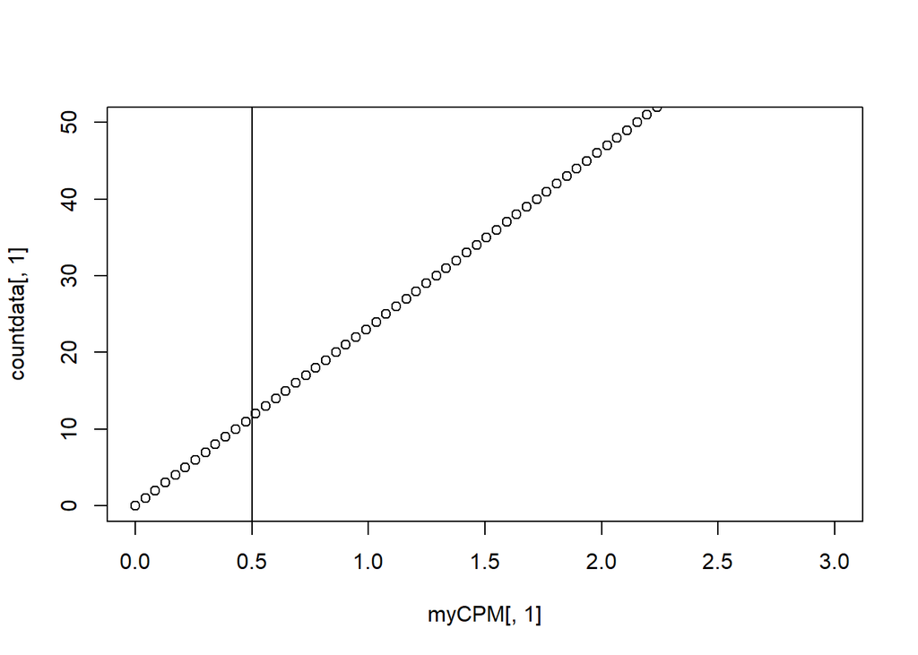

```r
# Need see whether our threshold of 0.5 does indeed correspond to a count of 10-15
plot(myCPM[, 1], countdata[,1], ylim=c(0,50), xlim=c(0,3))

abline(v=0.5)
```

## Quality Control

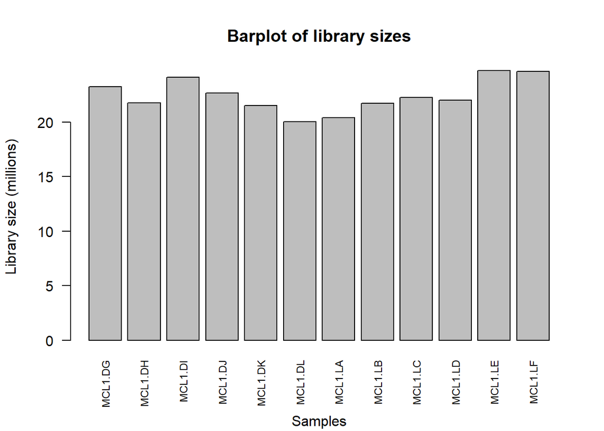

```r
# we can also adjust the labelling if we want
barplot(yDGElist$samples$lib.size/1e06, names=colnames(yDGElist), las=2, ann=FALSE, cex.names=0.75)
mtext(side = 1, text = "Samples", line = 4)
mtext(side = 2, text = "Library size (millions)", line = 3)
title("Barplot of library sizes")
```

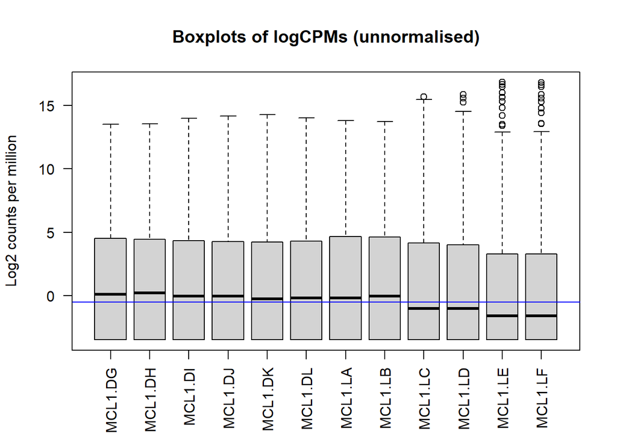

```r
# Get log2 counts per million
logcounts <- cpm(yDGElist,log=TRUE)
# Check distributions of samples using boxplots
boxplot(logcounts, xlab="", ylab="Log2 counts per million",las=2)
# Let's add a blue horizontal line that corresponds to the median logCPM
abline(h=median(logcounts),col="blue")
title("Boxplots of logCPMs (unnormalised)")
```

## Differential Expression

Differential Expression means we take the normalised read count data and perform statistical analysis to discover quantitative changes in expression levels between experimental groups.

```r
## Create a design Matrix
design <- model.matrix(~ 0 + group)

## Make the column names of the design matrix a bit nicer
colnames(design) <- levels(group)
design
```

```
##    basal.lactate basal.pregnant basal.virgin luminal.lactate luminal.pregnant
## 1              0              0            0               0                0
## 2              0              0            1               0                0
## 3              0              1            0               0                0
## 4              0              1            0               0                0
## 5              1              0            0               0                0
## 6              1              0            0               0                0
## 7              0              0            1               0                0
## 8              0              0            0               0                0
## 9              0              0            0               0                1
## 10             0              0            0               0                1
## 11             0              0            0               1                0
## 12             0              0            0               1                0
##    luminal.virgin
## 1               1
```

[output cut: 16 more lines]

## Voom the Data

Voom automatically adjusts the the library sizes and transforms the design matrix to product an Elist object. We then can plot a mean-variance trend of the data which will tell us if there is any genes that look variable in our data and if we have filtered correctly.

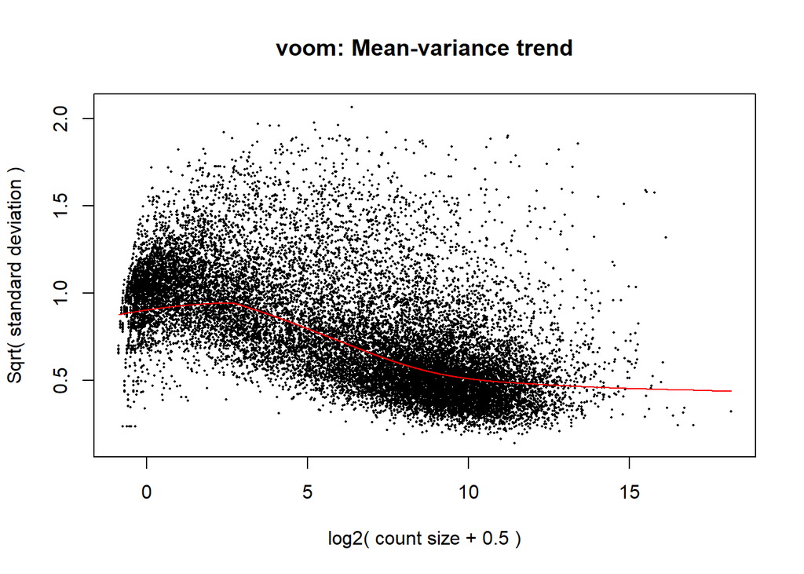

```r
par(mfrow=c(1,1))
v <- voom(yDGElist,design,plot = TRUE)
```

```r
v
```

```
## An object of class "EList"
## $targets
##                  group lib.size norm.factors
## MCL1.DG luminal.virgin 23227641            1
## MCL1.DH   basal.virgin 21777891            1
## MCL1.DI basal.pregnant 24100765            1
## MCL1.DJ basal.pregnant 22665371            1
## MCL1.DK  basal.lactate 21529331            1
## 7 more rows ...
##
## $E
##     MCL1.DG   MCL1.DH   MCL1.DI   MCL1.DJ   MCL1.DK   MCL1.DL    MCL1.LA
## 1  4.238662  3.786429  1.442416  3.389366  4.041410  3.844381 -5.3499394
## 2 -3.952808 -5.444792 -4.006045 -3.917455 -5.428232 -2.153113 -5.3499394
## 3 -5.537771 -5.444792 -5.591007 -5.502418 -5.428232 -5.323038 -5.3499394
## 4 -3.952808 -3.859830 -5.591007 -5.502418 -5.428232 -5.323038 -0.9576220
## 5  2.196939  3.066960  1.775315  2.218681  1.014712  2.043285 -0.3055453
##      MCL1.LB    MCL1.LC   MCL1.LD   MCL1.LE   MCL1.LF
## 1 -5.4401651 -5.4751892 -5.458660 -5.627830 -5.623943
## 2 -5.4401651 -5.4751892 -5.458660 -5.627830 -5.623943
## 3 -5.4401651 -5.4751892 -5.458660 -5.627830 -5.623943
## 4 -2.6328102 -1.0828718 -3.136732 -5.627830 -5.623943
## 5  0.2322603 -0.2657358 -1.371197 -2.820475 -1.231625
## 27174 more rows ...
##
## $weights
##          [,1]     [,2]     [,3]     [,4]     [,5]     [,6]     [,7]     [,8]
## [1,] 1.758725 1.623381 5.529302 5.324428 9.552025 9.191314 1.580440 1.708346
## [2,] 1.536668 1.699222 1.410071 1.422293 1.409001 1.423448 1.699222 1.555912
## [3,] 1.699222 1.699222 1.699222 1.699222 1.699222 1.699222 1.699222 1.699222
## [4,] 1.339465 1.280870 1.699222 1.699222 1.699222 1.699222 1.285784 1.349204
## [5,] 3.302221 3.397506 4.631417 4.463096 3.578174 3.432929 3.274575 3.180630
##          [,9]    [,10]    [,11]    [,12]
## [1,] 1.699222 1.699222 1.699222 1.699222
## [2,] 1.699222 1.699222 1.699222 1.699222
## [3,] 1.699222 1.699222 1.699222 1.699222
## [4,] 1.266922 1.267344 1.699222 1.699222
## [5,] 1.620439 1.612829 1.266515 1.266370
## 27174 more rows ...
##
## $design
##   basal.lactate basal.pregnant basal.virgin luminal.lactate luminal.pregnant
## 1             0              0            0               0                0
## 2             0              0            1               0                0
## 3             0              1            0               0                0
## 4             0              1            0               0                0
## 5             1              0            0               0                0
##   luminal.virgin
## 1              1
## 2              0
## 3              0
## 4              0
## 5              0
## 7 more rows ...
```

```r
# What is contained in this object?
names(v)
```

```
## [1] "targets" "E"       "weights" "design"
```

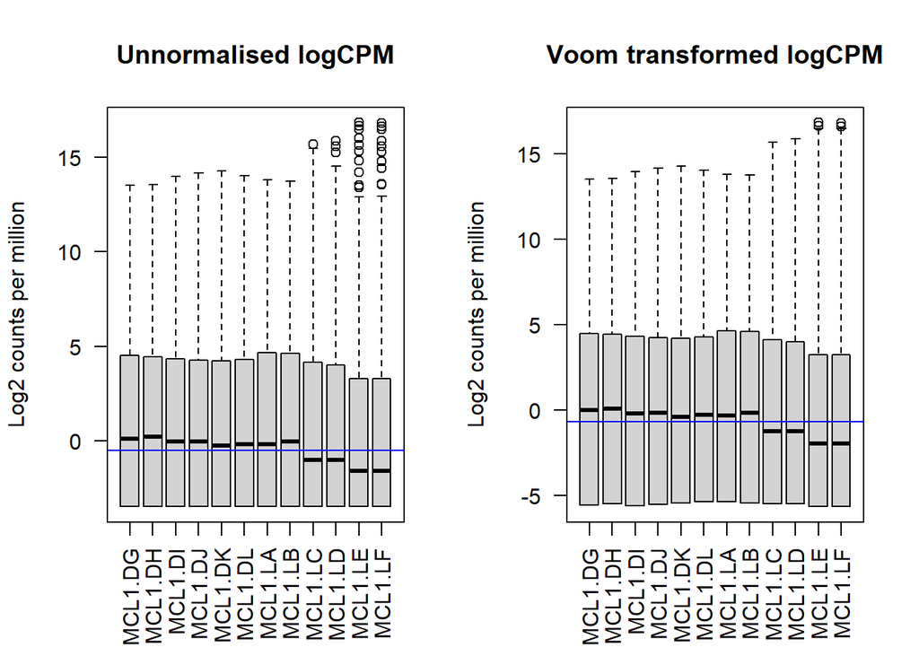

```r
# Compare Voom Transformation
par(mfrow=c(1,2))
boxplot(logcounts, xlab="", ylab="Log2 counts per million",las=2,main="Unnormalised logCPM")


abline(h=median(logcounts),col="blue")
boxplot(v$E, xlab="", ylab="Log2 counts per million",las=2,main="Voom transformed logCPM")

abline(h=median(v$E),col="blue")
```